# Pareto EFS - Step 5

Zahra Mungloo-Dilmohamud

3/18/2022

## Step 5. Use of MOO again on the merged list which ranked first to select one final merged list

Since in step 4, the all the rows are actually the average over 10 repeats, the final step now is to single out 1 feature subset from the 10. Therefore, the Novovicova metrics and the 3 performance metrics of the 10 repeats of highest ranking row from Step 4 are optimised using Pareto dominance. The number of FS methods involved in generating the merged list (number_of_methods) was not used here since the 10 repeats of the highest ranking combination are all derived from the same method combinations across multiple train/test sets.

The R code for performing this step has been provided below

```r
# Load the required packages
options(warn=-1)
library(caret)
library(data.table)
library(dplyr)
options(warn=0)
# #read the csv file and save as a dataframe

data_criteria_4_39582 <- read.csv('Stability_Performance_39582_10_repeats_v2.csv', header = TRUE)
num_rows <- nrow(data_criteria_4_39582)

dominates_matrix_4_39582 <- data.frame(
  Doubles=double(),
  Doubles=double(),
  stringsAsFactors=FALSE
)
names(dominates_matrix_4_39582)[1] <- "dominates"
names(dominates_matrix_4_39582)[2] <- "dominated"

dominates_matrix_4_39582_sorted <- data.frame(
  Doubles=double(),
  Doubles=double(),
  stringsAsFactors=FALSE
)

dominates_matrix_4_39582_freq <- data.frame(
  Doubles=double(),
  Doubles=double(),
  stringsAsFactors=FALSE
)

dominated_matrix_4_39582_freq <- data.frame(
  Doubles=double(),
  Doubles=double(),
  stringsAsFactors=FALSE
)

merge_matrix_4_39582_freq <- data.frame(
  Doubles=double(),
  Doubles=double(),
  Doubles=double(),
  Doubles=double(),
  stringsAsFactors=FALSE
)


# # For every possibility - every row in the file
 for(j in 1:num_rows){
   if(j+1<=num_rows){
   # print(j)
   # print("******************")
   for(i in j:(num_rows-1)){
     if (data_criteria_4_39582[j,2]==data_criteria_4_39582[i+1,2] && data_criteria_4_39582[j,6]==data_criteria_4_39582[i+1,6]&& data_criteria_4_39582[j,7]==data_criteria_4_39582[i+1,7]&& data_criteria_4_39582[j,8]==data_criteria_4_39582[i+1,8]){
       # to avoid counting dominance if both points have exactly the same values
     }
     else if (data_criteria_4_39582[j,2]>=data_criteria_4_39582[i+1,2] & data_criteria_4_39582[j,6]>=data_criteria_4_39582[i+1,6] & data_criteria_4_39582[j,7]>=data_criteria_4_39582[i+1,7] & data_criteria_4_39582[j,8]>=data_criteria_4_39582[i+1,8]){

     dominates_matrix_4_39582[nrow(dominates_matrix_4_39582) + 1,] = list(j,i+1)
     }
     else if(data_criteria_4_39582[i+1,2]>=data_criteria_4_39582[j,2] & data_criteria_4_39582[i+1,6]>=data_criteria_4_39582[j,6]& data_criteria_4_39582[i+1,7]>=data_criteria_4_39582[j,7]& data_criteria_4_39582[i+1,8]>=data_criteria_4_39582[j,8]){

     dominates_matrix_4_39582[nrow(dominates_matrix_4_39582) + 1,] = list(i+1,j)
     } #end of else

   } #end for i

   } #end of if j+1

 }


dominates_matrix_4_39582_sorted <- dominates_matrix_4_39582[order(dominates_matrix_4_39582$dominates),]
write.table(dominates_matrix_4_39582,"39582_4_metrics_sorted_train_test_10_repeats.csv", sep = ",", row.names = FALSE)

dominates_matrix_4_39582_freq <- as.data.frame(table(dominates_matrix_4_39582_sorted$dominates))
dominated_matrix_4_39582_freq <- as.data.frame(table(dominates_matrix_4_39582_sorted$dominated))

names(dominates_matrix_4_39582_freq)[1]<-"row_number"
names(dominates_matrix_4_39582_freq)[2]<-"frequency"
names(dominated_matrix_4_39582_freq)[1]<-"row_number"
names(dominated_matrix_4_39582_freq)[2]<-"frequency"

merge_matrix_4_39582_freq<- full_join(dominates_matrix_4_39582_freq, dominated_matrix_4_39582_freq, by = "row_number")

merge_matrix_4_39582_freq[is.na(merge_matrix_4_39582_freq)] <- 0

names(merge_matrix_4_39582_freq)[1]<-"row_number"
names(merge_matrix_4_39582_freq)[2]<-"dominates_freq"
names(merge_matrix_4_39582_freq)[3]<-"isDominated_freq"

merge_matrix_4_39582_freq$scalar_score <-merge_matrix_4_39582_freq$dominates_freq - merge_matrix_4_39582_freq$isDominated_freq
names(merge_matrix_4_39582_freq)[4]<-"scalar_score"

write.table(merge_matrix_4_39582_freq,"39582_4_metrics_10_repeats.csv", sep = ",", row.names = FALSE)
```

We now have a file containing the pareto for the 10 feature subsets for that combination of methods.

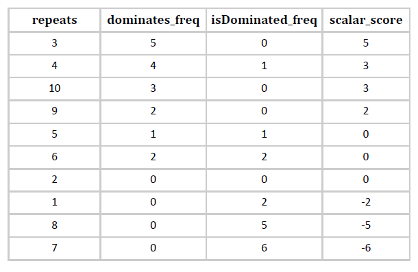

In this example, repeat 3 ranked first. Therefore, the resulting feature subset from the union of pairwise intersection for the 4 methods Correlation Feature Selection, ReliefF, SAM and SVM for repeat 3 is the recommended feature subset.

| Step 4 | Home |
| --- | --- |